# Relación entre los hábitos de sueño de estudiantes universitarios y su desempeño académico

## Modelos probabilísticos

### Variables discretas

1. Distribución binomial Variable utilizada: Desempeño Académico

```r
table(DP$DesempeñoA)
```

```
##
##  2  3  4  5
##  9 61 59  9
```

Caso: De una población de 138 personas de las cuales ninguna presenta un desempeño de nivel 1, 9 presentan un nivel 2, 61 personas de un nivel 3, 59 personas de nivel 4 y por último 9 personas de nivel 5, si escogemos aleatoriamente 40 personas. ¿Cuál es la probabilidad de tener 3 personas que hayan presentado un nivel 3 en desempeño?

X: número de personas con nivel de desempeño regular (3)

```r
#Para X=3
h <- 40 #número de ensayos
j <- 3 #número de personas con nivel 3 en desempeño
a <- 61/138 #probabilidad de éxito
dbinom(j,h,a)
```

```
## [1] 3.595339e-07
```

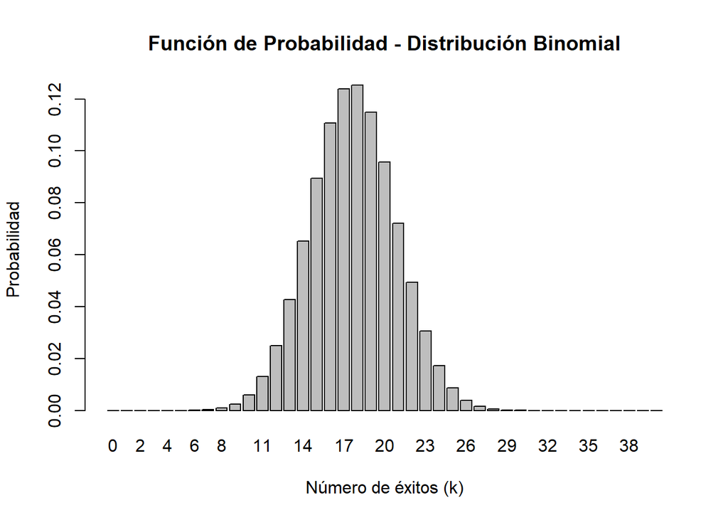

```r
j <- 0:h     # Valores posibles de j (número de éxitos)
prob <- dbinom(j, h, a)   # Probabilidad de cada valor de j

# Graficar los resultados
barplot(prob, names.arg = j, xlab = "Número de éxitos (k)", ylab = "Probabilidad",
        main = "Función de Probabilidad - Distribución Binomial")
```

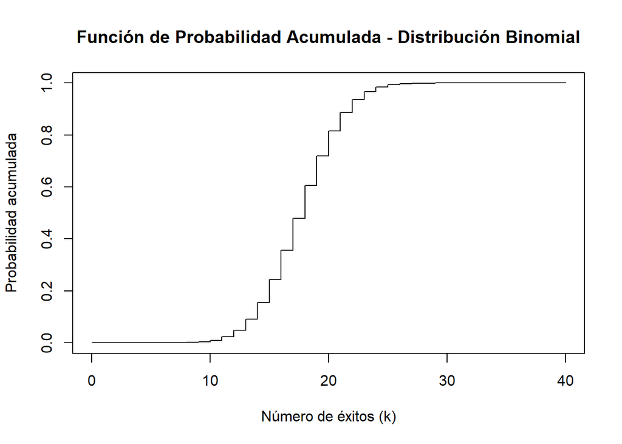

```r
p_acumulada <- pbinom(j, h, a)   # Probabilidad acumulada de cada valor de j

# Graficar los resultados
plot(j, p_acumulada, type = "s", ylim = c(0, 1),
     xlab = "Número de éxitos (k)", ylab = "Probabilidad acumulada",
     main = "Función de Probabilidad Acumulada - Distribución Binomial")
```

2. Distribución hipergeométrica Variable utilizada: Grupo Etario

```r
table(DP$GEtario)
```

```
##
##  Adolescente Adulto joven
##           52           86
```

Caso: Tenemos una población de 138 personas de las cuales 86 son Adultos jóvenes y 52 son adolescentes. Si se escogen aleatoriamente 30 personas sin reposición, ¿Cuál es la probabilidad de tener 17 adultos jóvenes?

X: número de adultos jóvenes obtenidos luego de haber escogido al azar a 30 personas de una muestra de 138.

```r
N <- 138  # Tamaño de la población
m <- 86   # Número de elementos "buenos" en la población
k <- 30   # Tamaño de la muestra
x <- 17   # Número de elementos "buenos" en la muestra
dhyper(x,m,N-m,k)
```

```
## [1] 0.1283808
```

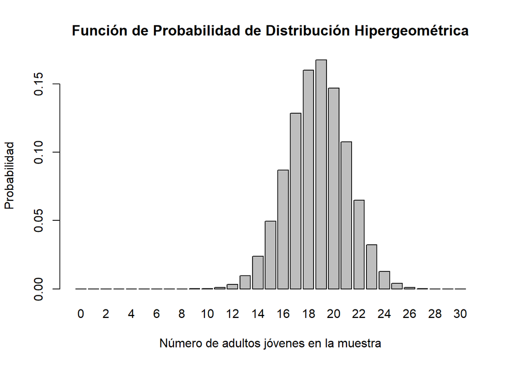

```r
probabilidades <- dhyper(0:k, m, N - m, k)

# Crear un vector con los valores x
valores_x <- 0:k

# Crear un gráfico de barras
barplot(probabilidades, names.arg = valores_x,
        xlab = "Número de adultos jóvenes en la muestra",
        ylab = "Probabilidad",
        main = "Función de Probabilidad de Distribución Hipergeométrica")
```

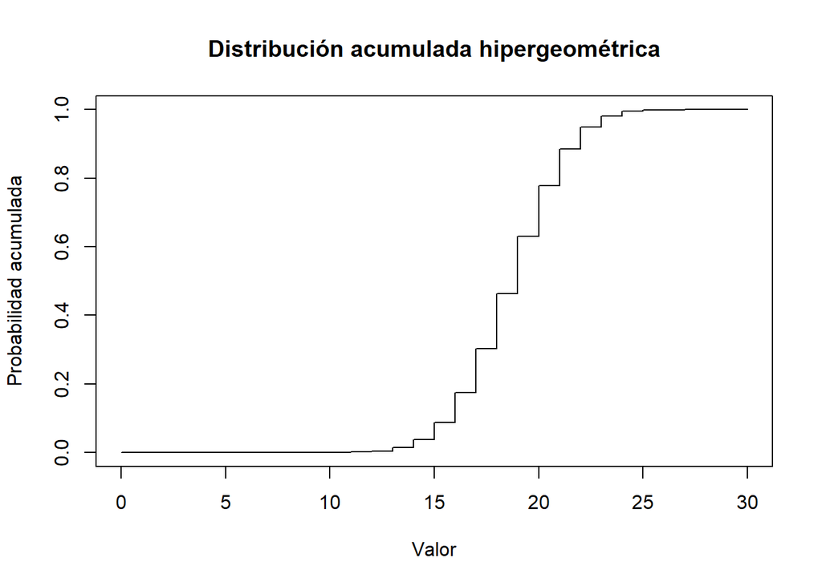

```r
v <- 0:k
prob_acumuladas <- phyper(v, m, N - m, k)

# Graficar la distribución acumulada
plot(v, prob_acumuladas, type = "s", xlab = "Valor", ylab = "Probabilidad acumulada", main = "Distribución acumulada hipergeométrica")
```

```r
EX <- k*(m/N)
cat("E(X):",EX,"\n")
```

```
## E(X): 18.69565
```

```r
VX <- k * (m / N) * ((N - m) / N) * ((N - k) / (N - 1))
cat("V(X):",VX,"\n")
```

```
## V(X): 5.553516
```

```r
SDX <- sqrt(VX)
cat("SD(X):",SDX)
```

```
## SD(X): 2.35659
```

### Variables continuas

1. Distribución normal Variable utilizada: Calidad de sueño

Paso 1:

```r
# Comprobar la simetría y la igualdad de la media y la mediana
simetria <- abs(mean(DP$CalidadS) - median(DP$CalidadS)) < 0.01
simetria
```

```
## [1] FALSE
```

```r
# Calcular la media y la esperanza de los datos
media <- mean(DP$CalidadS)
esperanza <- mean(DP$CalidadS)

# Comprobar que la media sea igual a la esperanza
media_correcta <- media == esperanza
media_correcta
```

```
## [1] TRUE
```

```r
# Calcular la varianza y la desviación estándar de los datos
varianza <- var(DP$CalidadS)
desviacion_estandar <- sqrt(varianza)

# Comprobar que la varianza sea igual a la desviación estándar
varianza_correcta <- varianza == desviacion_estandar^2
varianza_correcta
```

```
## [1] FALSE
```

Paso 2: Calcular la media y la desviación estándar de los datos

```r
media <- mean(DP$CalidadS)
media
```

```
## [1] 3.123188
```

```r
desviacion_estandar <- sd(DP$CalidadS)
desviacion_estandar
```

```
## [1] 0.923757
```

Paso 3: Ajustar los datos a una distribución normal

```r
x <- seq(min(DP$CalidadS), max(DP$CalidadS), length = 138)
y <- dnorm(x, mean = media, sd = desviacion_estandar)
```

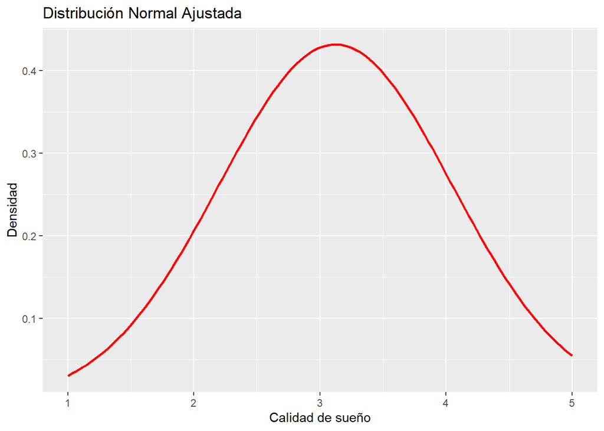

```r
ggplot(DP, aes(x = CalidadS)) +
  geom_line(aes(x = x, y = y), color = "red", size = 1) +
  ggtitle("Distribución Normal Ajustada") +
  xlab("Calidad de sueño") +
  ylab("Densidad")
```

Paso 4: Realizar análisis y cálculos adicionales

```r
evento3 <- 3  # Valor umbral para calcular la probabilidad
```

Caso: Calcular la probabilidad de que la variable aleatoria sea igual o menor a 3 utilizando la función pnorm()

```r
probabilidad_menor_igual <- pnorm(evento3, mean = media, sd = desviacion_estandar)

cat("La probabilidad de que la variable aleatoria sea igual o menor a", evento3, "es:", probabilidad_menor_igual)
```

```
## La probabilidad de que la variable aleatoria sea igual o menor a 3 es: 0.446956
```

2. Distribución exponencial Variable utilizada: Nivel de estrés

```r
media <- mean(DP$NEstres)
cat("Media:",round(media,digits=3))
```

```
## Media: 3.442
```

Caso: Tenemos una media de 3.442 para el nivel de estrés (entre alto y regular) para una población de 138 personas. ¿Cuál es la probabilidad de escoger un estudiante al azar que tenga un nivel de estrés menor a la media?

```r
#Para X<media
lambda=1/media
1-pexp(media, rate = lambda,lower.tail = FALSE)
```

```
## [1] 0.6321206
```

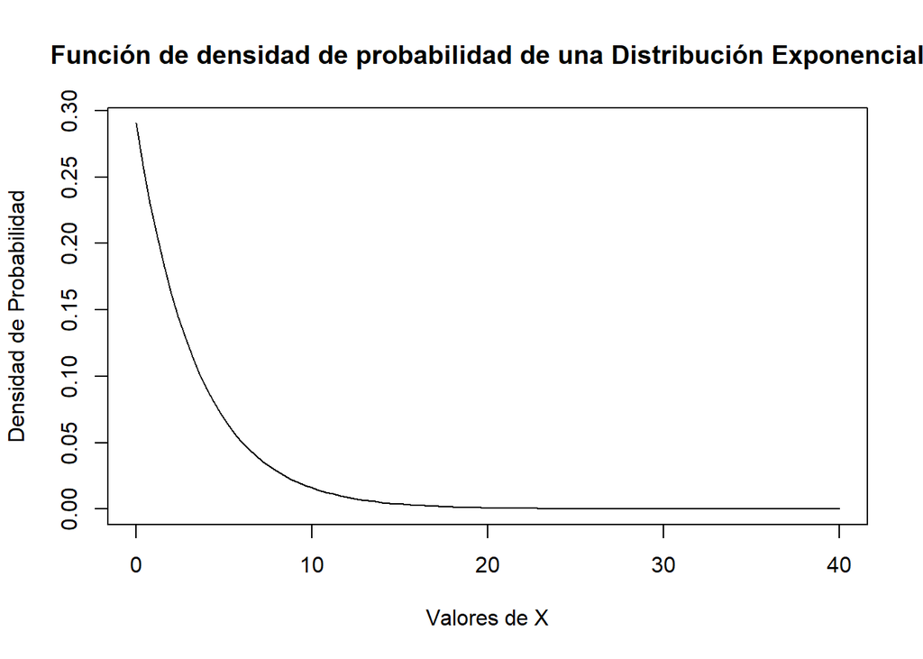

```r
#Para cualquier valor de X

curve(dexp(x, rate = lambda), xlim = c(0,40), xlab = "Valores de X", ylab = "Densidad de Probabilidad",main = "Función de densidad de probabilidad de una Distribución Exponencial")
```

```r
Esx <-1/lambda
Vzx <- 1/(Esx^2)
cat("Esperanza:", Esx, "\n")
```

```
## Esperanza: 3.442029
```

```r
cat("Varianza:", Vzx, "\n")
```

```
## Varianza: 0.08440554
```

# Conclusiones

- Logramos describir la relación entre los hábitos de sueño y desempeño académico de los estudiantes de UTEC.
- Evaluamos el impacto de los hábitos de sueño en la salud de los estudiantes, para esto utilizamos métodos probabilísticos como dependencia de eventos y los tipos de distribución. Además, nos apoyamos en las hipótesis vistas en el análisis descriptivo.
- Determinamos que los estudiantes universitarios, en su mayoría, no duermen lo suficiente según lo estipulado en diversas organizaciones médicas.

# Bibliografía

Lira, D., & Custodio, N. (2018). Los trastornos del sueño y su compleja relación con las funciones cognitivas. Revista De Neuro-Psiquiatría, 81(1), 20. https://doi.org/10.20453/rnp.v81i1.3270

Álvarez Navarrete, S., González Guarneros, G., Juárez Fernández, J. A., & Pérez, M. F. (2020). La calidad del sueño y su relación con la memoria en estudiantes universitarios. PsicoEducativa: Reflexiones Y Propuestas, 6(12), 17–25. https://psicoeducativa.edusol.info/index.php/rpsicoedu/article/view/122

Saavedra Torres, J. S., Zúñiga Cerón, L. F., Navia Amézquita, C. A. y Vásquez López, J. A. (2013). Ritmo circadiano: el reloj maestro. Alteraciones que comprometen el estado de sueño y vigilia en el área de la salud. Morfolia, 5(3). https://revistas.unal.edu.co/index.php/morfolia/article/view/41615

Pérez-Olmos, I., Talero-Gutiérrez, C., González-Reyes, R., & Moreno, C. B. (2006). Ritmos circadianos de sueño y rendimiento académico en estudiantes de medicina. Revista Ciencias de la Salud, 4(2), 147-157. http://www.scielo.org.co/scielo.php?script=sci_arttext&pid=S1692-72732006000200016

Rosales-Mayor, E. (2009). Estudio de validez y confiabilidad de la escala de somnolencia de Epworth en población peruana y modificación de la escala para población que no conduce vehículos motorizados [Tesis de Maestría]. Lima: facultad de Medicina, Universidad Peruana Cayetano Heredia. https://www.researchgate.net/publication/235220463_Estudio_de_validez_y_confiabilidad_de_la_Escala_de_Somnolencia_de_Epworth_en_poblacion_peruana_y_modificacion_de_la_escala_para_poblacion_que_no_conduce_vehiculos_motorizados

Suni, E., & Suni, E. (2023). How Much Sleep Do We Really Need? Sleep Foundation. https://www.sleepfoundation.org/how-sleep-works/how-much-sleep-do-we-really-need

Cote-Menéndez, M., Rangel-Garzón, C. X., Sánchez-Torres, M. Y., & Medina-Lemus, A. (2011). Bebidas energizantes:¿ Hidratantes o estimulantes?. Revista de la facultad de medicina, 59(3), 255-266 https://revistas.unal.edu.co/index.php/revfacmed/article/download/26461/38956?inline=1